# EE0848 Machine Learning for SP

Week 8: Unsupervised Learning

Basri Erdogan

# Unsupervised Learning

## Recap: Learning Paradigms

- **Supervised Learning:**
  - Learn mapping from inputs (X) to outputs (y)
  - Requires labeled data
  - Examples: Regression, Classification
- **Unsupervised Learning:**
  - Discover patterns/structure in data (X) itself
  - Only unlabeled data needed
  - Examples: Clustering, Dimensionality Reduction

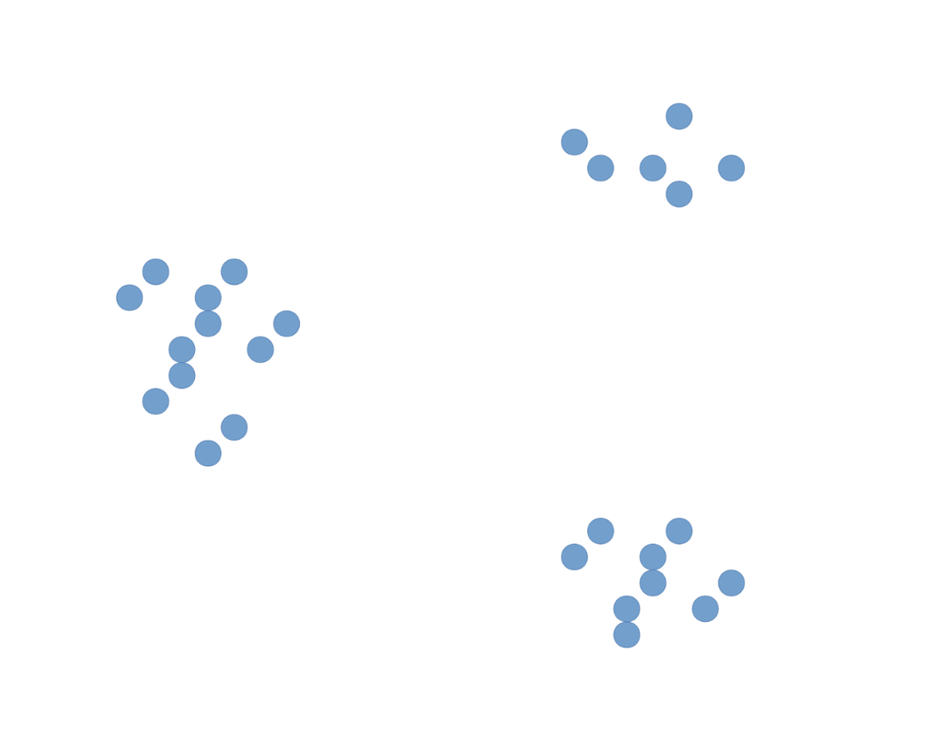

## What is Unsupervised Learning?

- The “less supervised” cousin in the ML family
- No explicit target variable `y` to predict
- Focus is on understanding the data’s inherent structure

**Key Goals:**

- Find groups (**clusters**) of similar data points
- Reduce the number of features (**dimensionality reduction**)
- Detect unusual data points (**anomaly detection**)
- Find co-occurring items (**association rules**)

## Today’s Focus

1. **Clustering:** Grouping similar data points together
   - K-Means Clustering
   - Hierarchical Clustering
   - DBSCAN
2. **Dimensionality Reduction:** Reducing features
   - Principal Component Analysis (PCA)
   - t-Distributed Stochastic Neighbor Embedding (t-SNE)

# Part 1: Clustering

## Clustering: Overview

**Goal:** Partition data points into groups (clusters) such that:

- Points *within* a cluster are similar
- Points *in different* clusters are dissimilar

**Why Cluster?**

- Understand underlying groupings in data
- Data exploration
- Preprocessing step for other algorithms

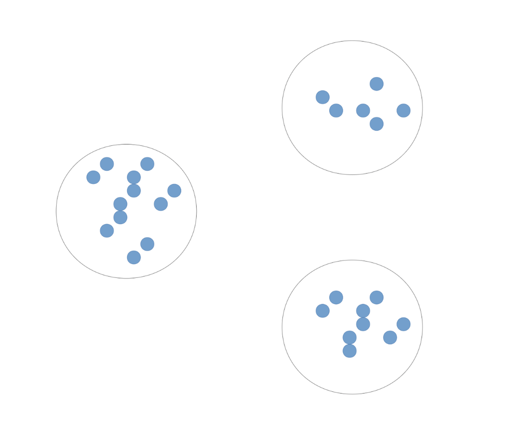

## Clustering Applications

- **Customer Segmentation:** Group customers based on purchasing behavior, demographics
- **Document Analysis:** Group similar documents or articles by topic
- **Image Segmentation:** Group pixels with similar colors/textures
- **Anomaly Detection:** Points not belonging to any cluster might be anomalies
- **Biology:** Group genes with similar expression patterns
- **Social Networks:** Identify communities

## Key Concept: Similarity / Distance

How do we measure if two points are “similar” or “close”?

**Common Distance Metrics:**

- **Euclidean Distance (L2 norm):** $\sqrt{\sum{(x_i - y_i)^2}}$
- **Manhattan Distance (L1 norm):** $\sum{|x_i - y_i|}$
- **Cosine Similarity:** $\frac{A \cdot B}{||A|| \; ||B||}$

*Choice of metric depends on the data and application.*

## Algorithm 1: K-Means Clustering

One of the simplest and most popular clustering algorithms.

**Goal:** Partition $N$ data points into $K$ clusters by minimizing within-cluster distances.

**The Algorithm:**

1. **Initialize:** Randomly choose $K$ centroids $\mu_1, \ldots, \mu_K$
2. **Assign:** Each point to nearest centroid: $\;c_i = \arg\min_k \|x_i - \mu_k\|^2$
3. **Update:** Recompute centroids: $\;\mu_k = \frac{1}{|C_k|}\sum_{x_i \in C_k} x_i$
4. **Repeat** steps 2–3 until convergence

**Objective (inertia):** $\;J = \sum_{k=1}^{K} \sum_{x_i \in C_k} \|x_i - \mu_k\|^2$

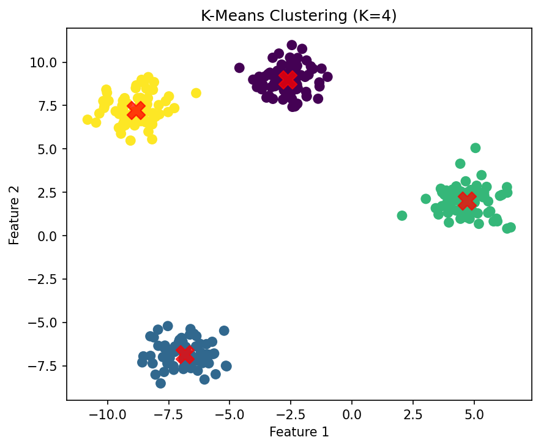

## K-Means: Simulation

[interactive chart not shown]

## K-Means: Pseudo-code

```python
def kmeans(X, K, max_iter=100):
    # Step 1: Initialize K random centroids
    centroids = randomly_select_k(X, K)

    for _ in range(max_iter):
        # Step 2: Assign each point to nearest centroid
        labels = [argmin(dist(x, c) for c in centroids) for x in X]

        # Step 3: Update centroids
        new_centroids = [mean(X[labels == k]) for k in range(K)]

        if converged(centroids, new_centroids):
            break
        centroids = new_centroids

    return labels, centroids
```

## K-Means: Scikit-learn Example

```python
from sklearn.datasets import make_blobs
from sklearn.cluster import KMeans

# 1. Generate sample data
X, _ = make_blobs(n_samples=300, centers=4, cluster_std=0.8, random_state=42)

# 2. Initialize and fit K-Means
kmeans = KMeans(n_clusters=4, random_state=42, n_init=10)
kmeans.fit(X)

# 3. Get cluster labels and centroids
labels = kmeans.labels_
centroids = kmeans.cluster_centers_

# 4. Visualize
plt.scatter(X[:, 0], X[:, 1], c=labels, s=50, cmap='viridis')
plt.scatter(centroids[:, 0], centroids[:, 1], c='red', s=200, alpha=0.75, marker='X')
plt.title('K-Means Clustering Results')
plt.show()

print(f"Cluster Centroids:\n{centroids}")
```

*Note: `n_init=10` runs the algorithm 10 times with different initial centroids and picks the best result.*

## K-Means: Choosing ‘K’ - The Elbow Method

K-Means requires specifying *K* beforehand.

**The Elbow Method:**

1. Run K-Means for a range of *K* values
2. Calculate Within-Cluster Sum of Squares (WCSS / Inertia)
3. Plot *K* vs. WCSS — look for the “elbow” where decrease levels off

$$WCSS = \sum_{k=1}^{K} \sum_{x_i \in C_k} ||x_i - \mu_k||^2$$

`inertia = kmeans.inertia_`

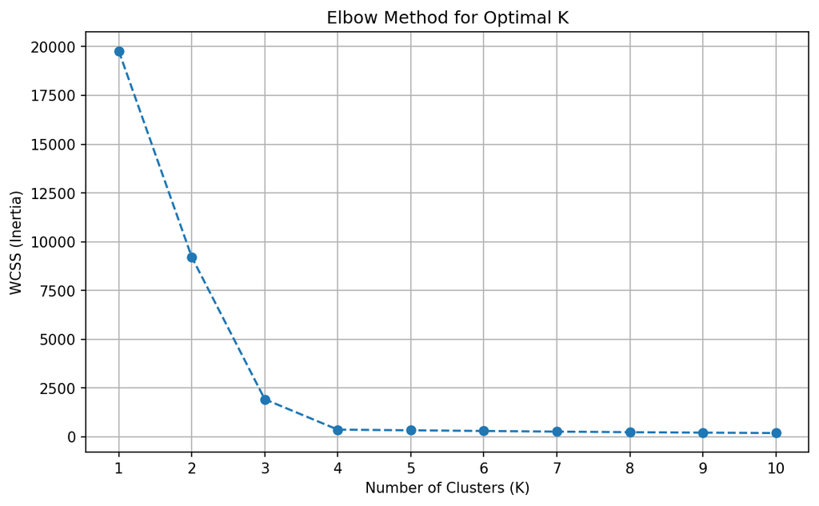

*Look for the ‘bend’ or ‘elbow’ (often K=4 here).*

## K-Means: Elbow Method (Code)

```python
wcss = []
k_range = range(1, 11)

for k in k_range:
    kmeans_k = KMeans(n_clusters=k, random_state=42, n_init=10)
    kmeans_k.fit(X)
    wcss.append(kmeans_k.inertia_)

plt.plot(k_range, wcss, marker='o', linestyle='--')
plt.title('Elbow Method for Optimal K')
plt.xlabel('Number of Clusters (K)')
plt.ylabel('Within-Cluster Sum of Squares (WCSS)')
plt.xticks(k_range)
plt.grid(True)
plt.show()
```

## K-Means: Pros and Cons

**Pros:**

- Simple and easy to understand
- Computationally efficient
- Widely used

**Cons:**

- Need to specify *K*
- Sensitive to initial centroids (use `n_init`)
- Assumes spherical, equally sized clusters
- Sensitive to outliers

## Algorithm 2: Hierarchical Clustering

- Builds a hierarchy of clusters
- Doesn’t require specifying *K* beforehand
- Types:
  - **Agglomerative (Bottom-up):** Merge closest clusters. *Most common.*
  - **Divisive (Top-down):** Split clusters.

## Hierarchical Clustering: Agglomerative

1. **Start:** Each point is its own cluster
2. **Merge:** Find and merge the two *closest* clusters
3. **Repeat:** Until one cluster remains

**Linkage Criteria** — define distance $d(A, B)$ between clusters $A$ and $B$

## Linkage Criteria: Mathematical Definitions

Let $A$, $B$ be clusters, $|A|$, $|B|$ their **number of points**, and $d(x, y)$ the distance between points.

- **Single linkage** (nearest neighbor):
  $$d_{\text{single}}(A, B) = \min_{x \in A,\; y \in B} d(x, y)$$
- **Complete linkage** (farthest neighbor):
  $$d_{\text{complete}}(A, B) = \max_{x \in A,\; y \in B} d(x, y)$$
- **Average linkage** (UPGMA):
  $$d_{\text{average}}(A, B) = \frac{1}{|A|\,|B|} \sum_{x \in A} \sum_{y \in B} d(x, y)$$
- **Ward linkage** — merge the pair that minimizes the increase in within-cluster variance:
  $$d_{\text{ward}}(A, B) = \frac{|A|\,|B|}{|A| + |B|} \, \lVert \bar{x}_A - \bar{x}_B \rVert^2$$
  where $\bar{x}_A$, $\bar{x}_B$ are the cluster centroids.

## Hierarchical Clustering: Dendrograms

- Visualizes the merge sequence
- **Height** = distance at merge point
- **Cut horizontally** to choose number of clusters

**How to read it:**

- Draw a horizontal line across the dendrogram
- Count vertical lines it intersects = number of clusters
- Higher threshold → fewer clusters, lower → more
- Choose based on domain knowledge or natural breaks

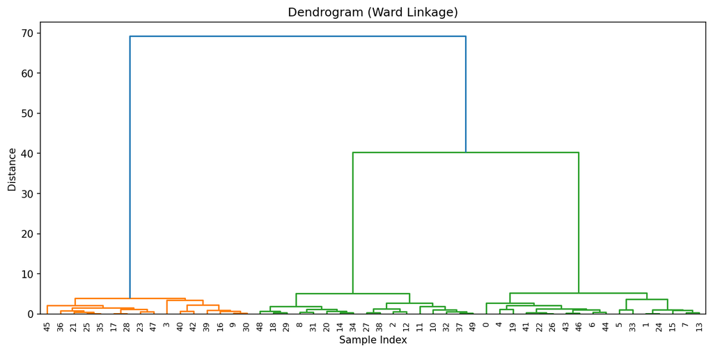

## Hierarchical Clustering: Simulation

[interactive chart not shown]

## Hierarchical Clustering: Scikit-learn Example

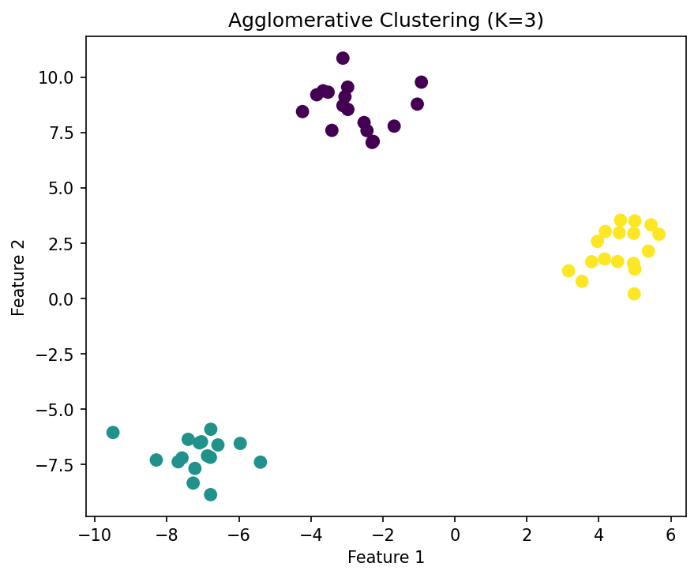

```python
from sklearn.cluster import AgglomerativeClustering
import scipy.cluster.hierarchy as sch

X, _ = make_blobs(n_samples=50, centers=3,
                  cluster_std=1.0, random_state=42)

# Create the dendrogram
sch.dendrogram(sch.linkage(X, method='ward'))
plt.title('Dendrogram (Ward Linkage)')
plt.show()

# Perform Agglomerative Clustering
agg = AgglomerativeClustering(
    n_clusters=3, linkage='ward'
)
labels = agg.fit_predict(X)

plt.scatter(X[:, 0], X[:, 1], c=labels,
            s=50, cmap='viridis')
plt.title('Agglomerative Clustering (k=3)')
plt.show()
```

## Hierarchical Clustering: Pros and Cons

**Pros:**

- No need to specify *K* upfront (dendrogram helps)
- Can capture nested structures
- Interpretable dendrogram

**Cons:**

- Computationally expensive ($O(n^2 \log n)$ or more)
- Sensitive to linkage criteria
- Merges are final (agglomerative)

## Algorithm 3: DBSCAN

- **D**ensity-**B**ased **S**patial **C**lustering of **A**pplications with **N**oise
- Groups dense regions, marks outliers as noise
- Parameters: `eps` (distance), `min_samples` (neighbors)

**Key Concepts:**

- **Core Point:** $\geq$ `min_samples` neighbors within `eps`
- **Border Point:** Reachable from core point, $<$ `min_samples` neighbors
- **Noise Point:** Neither core nor border

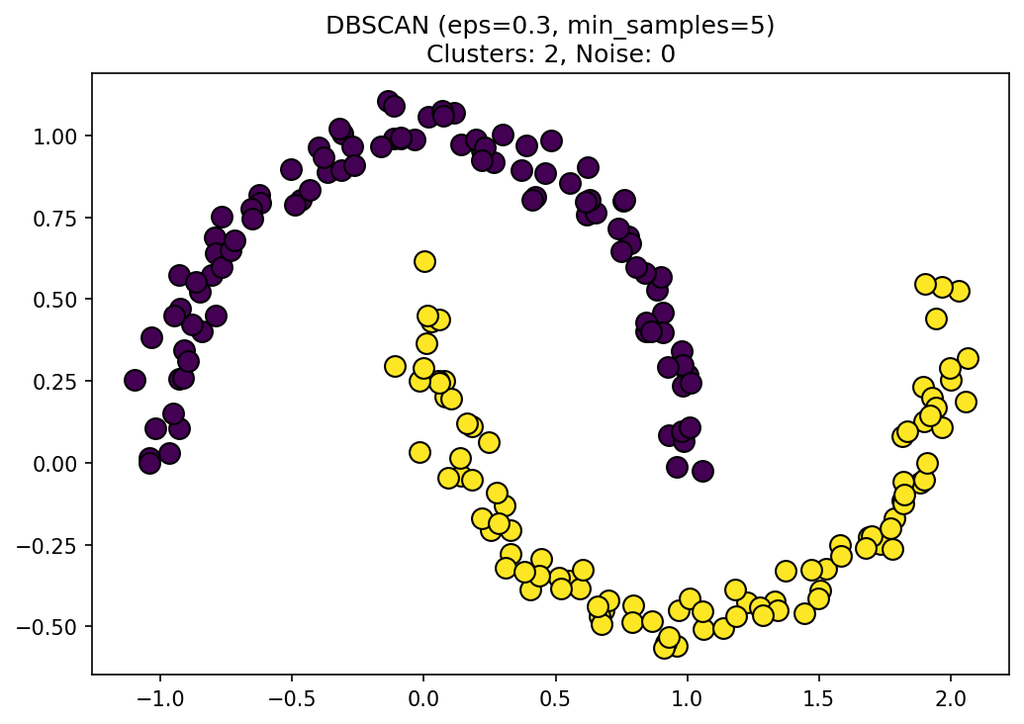

## DBSCAN: How it Works

1. **Pick** an unvisited point. Count neighbors within `eps` distance.
2. If neighbors $\geq$ `min_samples` → it’s a **core point**. Start a new cluster and add all neighbors.
3. **Expand:** For each neighbor that is also a core point, recursively add *its* neighbors to the cluster. Border points are added but not expanded from.
4. If neighbors $<$ `min_samples` and not reachable from any core point → mark as **noise**.
5. **Repeat** until all points are visited.

## DBSCAN: Scikit-learn Example

```python
from sklearn.datasets import make_moons
from sklearn.cluster import DBSCAN
import numpy as np

# 1. Generate sample data (non-convex shapes)
X, _ = make_moons(n_samples=200, noise=0.05, random_state=42)

# 2. Initialize and fit DBSCAN (Tuning eps/min_samples is crucial!)
dbscan = DBSCAN(eps=0.3, min_samples=5)
labels = dbscan.fit_predict(X)

# 3. Visualize (core vs border vs noise)
core_mask = np.zeros_like(labels, dtype=bool)
core_mask[dbscan.core_sample_indices_] = True

n_clusters = len(set(labels)) - (1 if -1 in labels else 0)
n_noise = list(labels).count(-1)
print(f"Estimated clusters: {n_clusters}, Noise points: {n_noise}")
```

## DBSCAN: Simulation

[interactive chart not shown]

## DBSCAN: Pros and Cons

**Pros:**

- No need to specify *K*
- Finds arbitrarily shaped clusters
- Robust to outliers (noise points)

**Cons:**

- Parameter tuning (`eps`, `min_samples`) can be hard
- Struggles with varying density clusters
- Sensitive to distance metric in high dimensions

## Clustering Evaluation

- **Internal (No True Labels): Assess Cohesion & Separation**
  - Key Metric: **Silhouette Score** (Higher is Better)
  - Others: Davies-Bouldin (Lower=Better), Calinski-Harabasz (Higher=Better)
- **External (Needs True Labels): Compare to Known Answer**
  - Key Metrics: **ARI**, **NMI** (Higher is Better)
  - Others: Homogeneity, Completeness, V-measure
- Use **internal** to tune parameters (like *K*), **external** to benchmark

## Silhouette Score: Definition

*Notation:* $C_I$ is the cluster containing point $i$; $|C_I|$ is its **number of points**; $d(\cdot, \cdot)$ is a distance metric (usually Euclidean).

**Cohesion** — mean distance from $i$ to all *other* points in its own cluster:

$$a(i) = \frac{1}{|C_I| - 1} \sum_{j \in C_I,\; j \neq i} d(i, j)$$

**Separation** — mean distance from $i$ to the *nearest* other cluster:

$$b(i) = \min_{J \neq I} \; \frac{1}{|C_J|} \sum_{j \in C_J} d(i, j)$$

**Silhouette of point $i$:**

$$s(i) = \frac{b(i) - a(i)}{\max\bigl(a(i),\, b(i)\bigr)} \;\in\; [-1,\, 1]$$

*Edge case:* if $|C_I| = 1$, define $s(i) = 0$.

**Overall silhouette score:**

$$S = \frac{1}{N} \sum_{i=1}^{N} s(i)$$

**Interpretation:** $s(i) \to 1$ well clustered; $\approx 0$ on a boundary; $< 0$ likely wrong cluster.

## Clustering Algorithms: Comparison

|  | **K-Means** | **Hierarchical** | **DBSCAN** |
| --- | --- | --- | --- |
| **Requires K** | Yes | Optional (dendrogram) | No |
| **Cluster shape** | Spherical | Any | Arbitrary |
| **Handles outliers** | No | No | Yes (noise label) |
| **Scalability** | Fast ($O(nKt)$) | Slow ($O(n^2 \log n)$) | Medium ($O(n \log n)$) |
| **Key parameter** | *K* | Linkage method | `eps`, `min_samples` |

# Part 2: Dimensionality Reduction

## Why Reduce Dimensions?

**Goal:** Reduce features (columns) while retaining essential information.

- **Curse of Dimensionality:** Performance degrades with too many features
- **Visualization:** Humans see in 2D/3D
- **Noise Reduction:** Remove irrelevant features
- **Efficiency:** Faster training/prediction
- **Compression:** Compact storage

## Technique 1: Principal Component Analysis (PCA)

- Widely used dimensionality reduction technique
- **Goal:** Find lower-dimensional subspace capturing max *variance*
- **How:** Identifies orthogonal directions (PCs) of max variance; projects data onto top *k* PCs

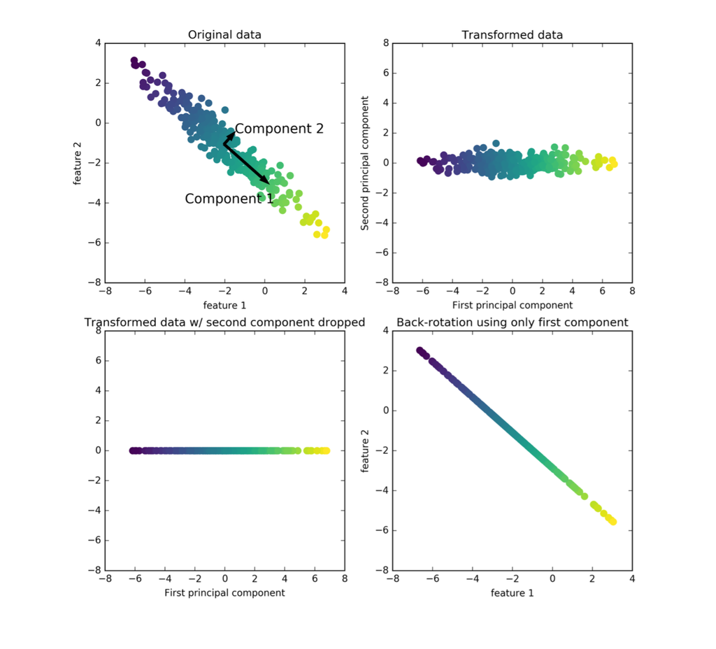

## PCA: Calculation Steps

1. **Center** the data: $\;X_{centered} = X - \bar{X}$
2. **Standardize** (recommended): $\;X_{std} = X_{centered} \, / \, \sigma$
3. **Compute SVD** (thin form, assuming $n \geq p$): $\;X_{std} = U \, S \, V^T$

| Matrix | Shape | Meaning |
| --- | --- | --- |
| $U$ | $n_{samples} \times p$ | Left singular vectors — sample coordinates (unit-length) |
| $S$ | $p \times p$ diagonal | Singular values $\sigma_1 \geq \sigma_2 \geq \cdots \geq \sigma_p \geq 0$ |
| $V^T$ | $p \times p$ | **Principal components** (rows) — directions in feature space |

*(where $p = n_{features}$; full SVD would give $U$ of shape $n \times n$, but the extra columns are padding and never used.)*

4. **Reduce:** Keep top $k$ rows of $V^T$ → project data onto $k$-dimensional subspace

**In one sentence:** SVD rewrites your data as *(rotated sample coordinates)* $\times$ *(how stretched each axis is)* $\times$ *(how to rotate back to original features)*. **PCA keeps the biggest stretches and throws the rest away.**

## PCA: Dimensionality Reduction Example

**Scenario:** $X_{std}$ is $1000 \times 30$ ($n = 1000$ samples, $p = 30$ features). Reduce to $k = 10$.

|  | $U$ | $S$ | $V^T$ |
| --- | --- | --- | --- |
| **Shape** | $1000 \times 30$ | $30 \times 30$ | $30 \times 30$ |
| **Meaning** | Sample scores | Singular values (diagonal) | Principal components (rows) |

**Step 2 — Truncate** to top $k=10$ singular values (largest variance):

|  | $V_k^T$ | $S_k$ | $U_k$ |
| --- | --- | --- | --- |
| **Shape** | $\mathbf{10} \times 30$ | $\mathbf{10} \times \mathbf{10}$ | $1000 \times \mathbf{10}$ |
| **Kept** | First 10 rows | Top-left 10×10 block | First 10 columns |
| **Intuition** | 10 **new axes** — each row is a “recipe” mixing the 30 original features | **importance** of each axis — how much variance it captures | **coordinates** of each sample on the 10 new axes |

**Step 3 — Project:** $\;X_{pca} = X_{std} \, V_k = U_k \, S_k$ → shape: $1000 \times \mathbf{10}$

*Each sample now lives in a 10D space defined by the directions that capture the most variance.*

## PCA: Intuition

1. Find direction of largest variance (**PC1**)
2. Find next orthogonal direction with largest remaining variance (**PC2**)
3. … repeat …
4. Keep top *k* PCs that capture desired variance
5. Transform data onto this *k*-dimensional subspace

*Requires Data Standardization!*

## PCA: Scikit-learn Example

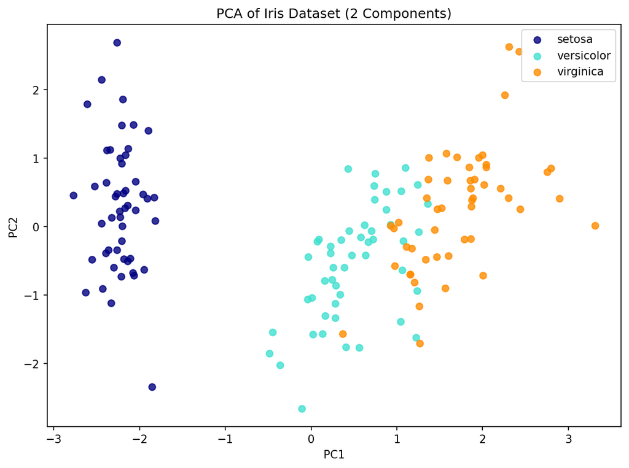

```python
from sklearn.datasets import load_iris
from sklearn.preprocessing import StandardScaler
from sklearn.decomposition import PCA

# 1. Load and standardize data
iris = load_iris()
scaler = StandardScaler()
X_scaled = scaler.fit_transform(iris.data)

# 2. Apply PCA (reduce to 2D)
pca = PCA(n_components=2)
X_pca = pca.fit_transform(X_scaled)

# 3. Visualize
plt.scatter(X_pca[:, 0], X_pca[:, 1],
            c=iris.target, cmap='viridis')
plt.xlabel('PC1')
plt.ylabel('PC2')
plt.title('PCA of Iris Dataset')
plt.show()

# 4. Explained Variance
print(pca.explained_variance_ratio_)
# [0.7296, 0.2285] → total: 95.8%
```

## PCA: Choosing the Number of Components

How many components (*k*) to keep?

- Plot **cumulative explained variance**
- Choose *k* to retain desired variance (e.g., 95%)

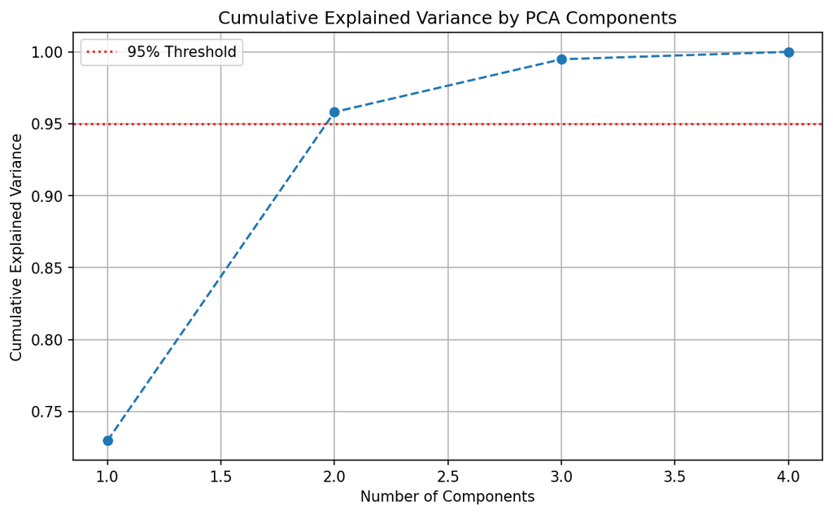

```python
pca_full = PCA().fit(X_scaled)
cum_var = np.cumsum(
    pca_full.explained_variance_ratio_
)
plt.plot(range(1, len(cum_var)+1),
         cum_var, marker='o')
plt.axhline(y=0.95, color='r', linestyle=':')
plt.show()

# Let sklearn choose automatically
pca_95 = PCA(n_components=0.95)
X_pca_95 = pca_95.fit_transform(X_scaled)
print(pca_95.n_components_)  # 2
```

## Technique 2: t-SNE

- **t**-Distributed **S**tochastic **N**eighbor **E**mbedding
- Primarily a **visualization** technique
- Helps visualize local structures and clusters within high-dimensional data by projecting it into 2D or 3D
- **Goal:** Model similarities in a low-dimensional map
- **Key Parameter:** `perplexity` (effective number of neighbors, typically 5-50)

*Computationally expensive, often run after PCA to reduce input dimensions first.*

## t-SNE: Scikit-learn Example

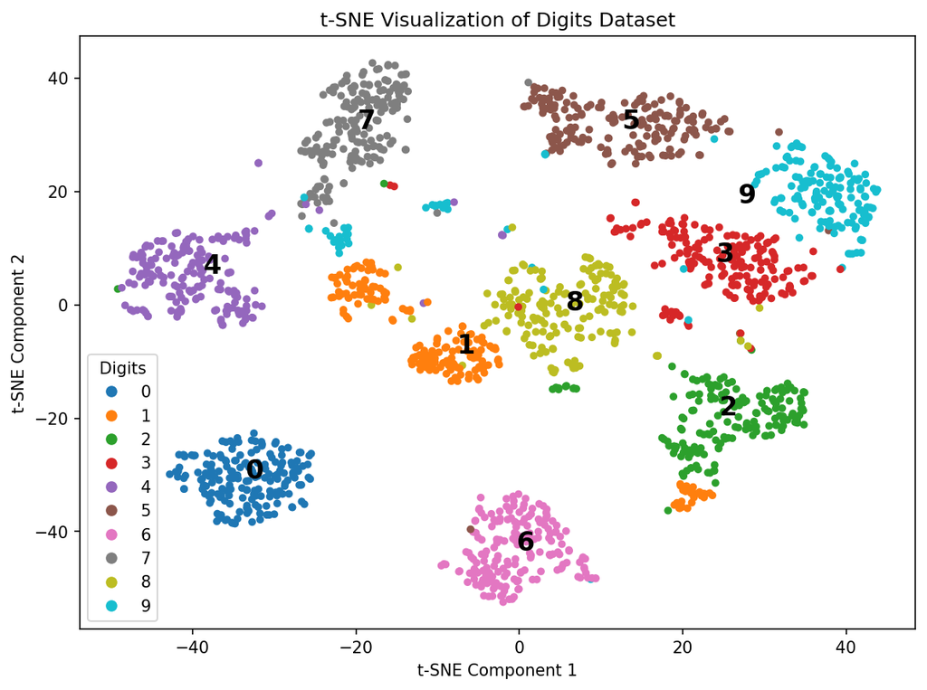

```python
from sklearn.datasets import load_digits
from sklearn.preprocessing import StandardScaler
from sklearn.manifold import TSNE

# 1. Load and scale data
digits = load_digits()
X_scaled = StandardScaler().fit_transform(
    digits.data
)

# 2. Apply t-SNE (can take time!)
tsne = TSNE(
    n_components=2,
    perplexity=30,
    max_iter=1000,
    init='pca',
    learning_rate='auto',
    random_state=42
)
X_tsne = tsne.fit_transform(X_scaled)

# 3. Visualize
plt.scatter(X_tsne[:, 0], X_tsne[:, 1],
            c=digits.target, s=14,
            cmap='tab10')
plt.title('t-SNE of Digits Dataset')
plt.show()
```

## t-SNE: When to Use It

*Local structure is trustworthy; global structure (cluster positions, sizes, inter-cluster distances) is not.*

**Good use cases:**

- **Cluster discovery** — does a high-dim dataset split into groups? How many?
- **Sanity-checking learned representations** — run on penultimate-layer activations of a trained NN; classes should separate
- **Outlier visibility** — points that don’t fit any cluster stand out
- **Class mixing diagnosis** — overlapping colored blobs reveal confusable classes
- **Communication** — a 2D picture is easier to share than “17 dense regions in 50-D space”

**Avoid for:**

- **Preprocessing for downstream ML** (no `.transform()`; distances meaningless)
- **Quantitative distance queries** — use original high-D distances
- **Measuring cluster quality** (silhouette on t-SNE = artifact)

**Responsible use:**

- Run multiple random seeds — trust what’s stable
- Try perplexity $\in \{5, 30, 50\}$
- Pre-reduce with PCA (to ~50 dims) first
- Consider **UMAP** as a modern alternative that preserves more global structure

## Summary

**Clustering:**

- **K-Means:** Simple, fast, needs *K*, spherical clusters
- **Hierarchical:** Dendrogram for exploring *K*, computationally expensive
- **DBSCAN:** Density-based, handles noise and arbitrary shapes, parameter-sensitive

**Dimensionality Reduction:**

- **PCA:** Linear, preserves global variance, choose *k* via explained variance
- **t-SNE:** Non-linear, great for visualization, not for preprocessing

**Key takeaways:**

- Use **internal metrics** (silhouette) to tune clustering parameters
- Always **standardize** data before PCA
- t-SNE is for **visualization only**, not a general-purpose reducer

## Next Week

**Neural Networks**

- Perceptrons and multi-layer networks
- Activation functions
- Backpropagation
- Training deep networks with PyTorch